# HeartAttack&Prediction Analysis

Malay Raj

2023-09-26

## HEART ATTACK & PREDICTION ANALYSIS:

This dataset contains information about people’s health, including details such as age, sex, chest pain, etc.

## Loading Required Packages.

```r
library(tidyverse)
library(janitor)
```

```r
library(dplyr)
library(ggplot2)
library(skimr)
library(plyr)
library(lubridate)
library(plotly)
library(gridExtra)
```

## Displaying my current working directory.

```r
getwd()
```

```
## [1] "C:/Heart Attack & Prediction Analysis"
```

## Collecting the data.

```r
heart = read.csv("C:/Heart Attack & Prediction Analysis/heart.csv")
```

## Displaying the first six rows of dataset.

```r
head(heart)
```

```
##   age sex cp trtbps chol fbs restecg thalachh exng oldpeak slp caa thall output
## 1  63   1  3    145  233   1       0      150    0     2.3   0   0     1      1
## 2  37   1  2    130  250   0       1      187    0     3.5   0   0     2      1
## 3  41   0  1    130  204   0       0      172    0     1.4   2   0     2      1
## 4  56   1  1    120  236   0       1      178    0     0.8   2   0     2      1
## 5  57   0  0    120  354   0       1      163    1     0.6   2   0     2      1
## 6  57   1  0    140  192   0       1      148    0     0.4   1   0     1      1
```

## Checking the dimension of the dataset.

```r
dim(heart)
```

```
## [1] 303  14
```

## Displaying the column names of our dataframe.

```r
colnames(heart)
```

```
##  [1] "age"      "sex"      "cp"       "trtbps"   "chol"     "fbs"
##  [7] "restecg"  "thalachh" "exng"     "oldpeak"  "slp"      "caa"
## [13] "thall"    "output"
```

## Inspecting the dataframe and look for inconguencies.

```r
str(heart)
```

```
## 'data.frame':    303 obs. of  14 variables:
##  $ age     : int  63 37 41 56 57 57 56 44 52 57 ...
##  $ sex     : int  1 1 0 1 0 1 0 1 1 1 ...
##  $ cp      : int  3 2 1 1 0 0 1 1 2 2 ...
##  $ trtbps  : int  145 130 130 120 120 140 140 120 172 150 ...
##  $ chol    : int  233 250 204 236 354 192 294 263 199 168 ...
##  $ fbs     : int  1 0 0 0 0 0 0 0 1 0 ...
##  $ restecg : int  0 1 0 1 1 1 0 1 1 1 ...
##  $ thalachh: int  150 187 172 178 163 148 153 173 162 174 ...
##  $ exng    : int  0 0 0 0 1 0 0 0 0 0 ...
##  $ oldpeak : num  2.3 3.5 1.4 0.8 0.6 0.4 1.3 0 0.5 1.6 ...
##  $ slp     : int  0 0 2 2 2 1 1 2 2 2 ...
##  $ caa     : int  0 0 0 0 0 0 0 0 0 0 ...
##  $ thall   : int  1 2 2 2 2 1 2 3 3 2 ...
##  $ output  : int  1 1 1 1 1 1 1 1 1 1 ...
```

## Chaning few names of few columns in our dataset.

```r
heart = plyr::rename(heart, replace=c("cp" = "chest_pain",
                                      "fbs" = "fasting_blood_sugar",
                                      "exng" = "exercise_induced_angina",
                                      "slp" = "slope",
                                      "thall" = "thalassemia",
                                      "output" = "target"))
```

## Checking the column names of our new columns.

```r
colnames(heart)
```

```
##  [1] "age"                     "sex"
##  [3] "chest_pain"              "trtbps"
##  [5] "chol"                    "fasting_blood_sugar"
##  [7] "restecg"                 "thalachh"
##  [9] "exercise_induced_angina" "oldpeak"
## [11] "slope"                   "caa"
## [13] "thalassemia"             "target"
```

## Checking for null values in our dataset.

```r
null_sum <- colSums(is.na(heart))
null_sum
```

```
##                     age                     sex              chest_pain
##                       0                       0                       0
##                  trtbps                    chol     fasting_blood_sugar
##                       0                       0                       0
##                 restecg                thalachh exercise_induced_angina
##                       0                       0                       0
##                 oldpeak                   slope                     caa
##                       0                       0                       0
##             thalassemia                  target
##                       0                       0
```

## Checking for any duplicate values in our dataset.

```r
anyDuplicated(heart)
```

```
## [1] 165
```

## Removing those duplicate values.

```r
heart = unique(heart)
anyDuplicated(heart)
```

```
## [1] 0
```

## Checking for the current dimensions of our dataset.

```r
dim(heart)
```

```
## [1] 302  14
```

## Seeing how many observations fall under each of these columns.

```r
table(heart$age)
```

```
##
## 29 34 35 37 38 39 40 41 42 43 44 45 46 47 48 49 50 51 52 53 54 55 56 57 58 59
##  1  2  4  2  2  4  3 10  8  8 11  8  7  5  7  5  7 12 13  8 16  8 11 17 19 14
## 60 61 62 63 64 65 66 67 68 69 70 71 74 76 77
## 11  8 11  9 10  8  7  9  4  3  4  3  1  1  1
```

```r
table(heart$sex)
```

```
##
##   0   1
##  96 206
```

```r
table(heart$chest_pain)
```

```
##
##   0   1   2   3
## 143  50  86  23
```

```r
table(heart$trtbps)
```

```
##
##  94 100 101 102 104 105 106 108 110 112 114 115 117 118 120 122 123 124 125 126
##   2   4   1   2   1   3   1   6  19   9   1   3   1   7  37   4   1   6  11   3
## 128 129 130 132 134 135 136 138 140 142 144 145 146 148 150 152 154 155 156 160
##  12   1  36   8   5   6   3  12  32   3   2   5   2   2  17   5   1   1   1  11
## 164 165 170 172 174 178 180 192 200
##   1   1   4   1   1   2   3   1   1
```

```r
table(heart$chol)
```

```
##
## 126 131 141 149 157 160 164 166 167 168 169 172 174 175 176 177 178 180 182 183
##   1   1   1   2   1   1   1   1   1   1   1   1   1   2   1   4   1   1   1   1
## 184 185 186 187 188 192 193 195 196 197 198 199 200 201 203 204 205 206 207 208
##   1   1   1   1   2   2   2   1   2   6   2   3   1   3   3   6   2   2   2   2
## 209 210 211 212 213 214 215 216 217 218 219 220 221 222 223 224 225 226 227 228
##   2   1   4   5   2   2   1   2   1   2   3   3   2   2   3   1   2   4   2   2
## 229 230 231 232 233 234 235 236 237 239 240 241 242 243 244 245 246 247 248 249
##   3   3   3   2   4   6   2   3   1   4   4   1   1   4   3   3   3   2   2   3
## 250 252 253 254 255 256 257 258 259 260 261 262 263 264 265 266 267 268 269 270
##   3   1   2   5   2   3   1   3   1   2   2   1   3   2   2   2   2   2   5   2
## 271 273 274 275 276 277 278 281 282 283 284 286 288 289 290 293 294 295 298 299
##   2   2   3   2   1   2   1   1   4   3   1   2   3   2   1   1   2   2   2   2
## 300 302 303 304 305 306 307 308 309 311 313 315 318 319 321 322 325 326 327 330
##   1   2   3   2   1   1   1   2   3   1   1   2   2   1   1   1   2   1   1   2
## 335 340 341 342 353 354 360 394 407 409 417 564
##   2   1   1   1   1   1   1   1   1   1   1   1
```

```r
table(heart$fasting_blood_sugar)
```

```
##
##   0   1
## 257  45
```

```r
table(heart$restecg)
```

```
##
##   0   1   2
## 147 151   4
```

```r
table(heart$thalachh)
```

```
##
##  71  88  90  95  96  97  99 103 105 106 108 109 111 112 113 114 115 116 117 118
##   1   1   1   1   2   1   1   2   3   1   2   2   3   2   1   3   3   2   1   1
## 120 121 122 123 124 125 126 127 128 129 130 131 132 133 134 136 137 138 139 140
##   3   1   4   2   1   7   4   1   1   1   4   4   7   2   1   2   1   3   2   6
## 141 142 143 144 145 146 147 148 149 150 151 152 153 154 155 156 157 158 159 160
##   3   6   7   7   4   4   5   3   2   7   4   8   3   5   4   6   5   6   4   9
## 161 162 163 164 165 166 167 168 169 170 171 172 173 174 175 177 178 179 180 181
##   5  11   9   2   5   3   1   5   6   5   4   7   7   5   3   1   5   5   2   2
## 182 184 185 186 187 188 190 192 194 195 202
##   5   1   1   2   1   1   1   1   1   1   1
```

```r
table(heart$exercise_induced_angina)
```

```
##
##   0   1
## 203  99
```

```r
table(heart$oldpeak)
```

```
##
##   0 0.1 0.2 0.3 0.4 0.5 0.6 0.7 0.8 0.9   1 1.1 1.2 1.3 1.4 1.5 1.6 1.8 1.9   2
##  98   7  12   3   9   5  14   1  13   3  14   2  17   1  13   5  11  10   5   9
## 2.1 2.2 2.3 2.4 2.5 2.6 2.8 2.9   3 3.1 3.2 3.4 3.5 3.6 3.8   4 4.2 4.4 5.6 6.2
##   1   4   2   3   2   6   6   1   5   1   2   3   1   4   1   3   2   1   1   1
```

```r
table(heart$slope)
```

```
##
##   0   1   2
##  21 140 141
```

```r
table(heart$caa)
```

```
##
##   0   1   2   3   4
## 175  65  38  20   4
```

```r
table(heart$thalassemia)
```

```
##
##   0   1   2   3
##   2  18 165 117
```

```r
table(heart$target)
```

```
##
##   0   1
## 138 164
```

## CONDUCTNG DESCRIPTIVE ANALYSIS:

Descriptive analysis on few columns of our dataset.

```r
summary(heart$age)
```

```
##    Min. 1st Qu.  Median    Mean 3rd Qu.    Max.
##   29.00   48.00   55.50   54.42   61.00   77.00
```

```r
summary(heart$trtbps)
```

```
##    Min. 1st Qu.  Median    Mean 3rd Qu.    Max.
##    94.0   120.0   130.0   131.6   140.0   200.0
```

```r
summary(heart$chol)
```

```
##    Min. 1st Qu.  Median    Mean 3rd Qu.    Max.
##   126.0   211.0   240.5   246.5   274.8   564.0
```

```r
summary(heart$thalachh)
```

```
##    Min. 1st Qu.  Median    Mean 3rd Qu.    Max.
##    71.0   133.2   152.5   149.6   166.0   202.0
```

```r
summary(heart$oldpeak)
```

```
##    Min. 1st Qu.  Median    Mean 3rd Qu.    Max.
##   0.000   0.000   0.800   1.043   1.600   6.200
```

Comparing different columns with each other from each of our dataset.

```r
aggregate(heart$trtbps ~ heart$age, data = heart, FUN = mean)
```

```
##    heart$age heart$trtbps
## 1         29     130.0000
## 2         34     118.0000
## 3         35     126.5000
## 4         37     125.0000
## 5         38     129.0000
## 6         39     122.5000
## 7         40     134.0000
## 8         41     119.0000
## 9         42     127.0000
## 10        43     126.3750
## 11        44     120.7273
## 12        45     122.3750
## 13        46     128.0000
## 14        47     119.6000
```

[output cut: 27 more lines]

```r
aggregate(heart$trtbps ~ heart$age, data = heart, FUN = median)
```

```
##    heart$age heart$trtbps
## 1         29        130.0
## 2         34        118.0
## 3         35        124.0
## 4         37        125.0
## 5         38        129.0
## 6         39        128.0
## 7         40        140.0
## 8         41        116.0
## 9         42        125.0
## 10        43        126.0
## 11        44        120.0
## 12        45        121.5
## 13        46        138.0
## 14        47        112.0
```

[output cut: 27 more lines]

```r
aggregate(heart$trtbps ~ heart$age, data = heart, FUN = max)
```

```
##    heart$age heart$trtbps
## 1         29          130
## 2         34          118
## 3         35          138
## 4         37          130
## 5         38          138
## 6         39          140
## 7         40          152
## 8         41          135
## 9         42          148
## 10        43          150
## 11        44          140
## 12        45          142
## 13        46          150
## 14        47          138
```

[output cut: 27 more lines]

```r
aggregate(heart$trtbps ~ heart$age, data = heart, FUN = min)
```

```
##    heart$age heart$trtbps
## 1         29          130
## 2         34          118
## 3         35          120
## 4         37          120
## 5         38          120
## 6         39           94
## 7         40          110
## 8         41          105
## 9         42          102
## 10        43          110
## 11        44          108
## 12        45          104
## 13        46          101
## 14        47          108
```

[output cut: 27 more lines]

```r
aggregate(heart$chol ~ heart$age, data = heart, FUN = mean)
```

```
##    heart$age heart$chol
## 1         29   204.0000
## 2         34   196.0000
## 3         35   213.7500
## 4         37   232.5000
## 5         38   203.0000
## 6         39   239.7500
## 7         40   196.3333
## 8         41   220.7000
## 9         42   246.7500
## 10        43   256.7500
## 11        44   221.3636
## 12        45   247.3750
## 13        46   230.2857
## 14        47   246.4000
```

[output cut: 27 more lines]

```r
aggregate(heart$chol ~ heart$age, data = heart, FUN = median)
```

```
##    heart$age heart$chol
## 1         29      204.0
## 2         34      196.0
## 3         35      195.0
## 4         37      232.5
## 5         38      203.0
## 6         39      219.5
## 7         40      199.0
## 8         41      209.0
## 9         42      242.0
## 10        43      247.0
## 11        44      226.0
## 12        45      248.0
## 13        46      231.0
## 14        47      253.0
```

[output cut: 27 more lines]

```r
aggregate(heart$chol ~ heart$age, data = heart, FUN = max)
```

```
##    heart$age heart$chol
## 1         29        204
## 2         34        210
## 3         35        282
## 4         37        250
## 5         38        231
## 6         39        321
## 7         40        223
## 8         41        306
## 9         42        315
## 10        43        341
## 11        44        290
## 12        45        309
## 13        46        311
## 14        47        275
```

[output cut: 27 more lines]

```r
aggregate(heart$chol ~ heart$age, data = heart, FUN = min)
```

```
##    heart$age heart$chol
## 1         29        204
## 2         34        182
## 3         35        183
## 4         37        215
## 5         38        175
## 6         39        199
## 7         40        167
## 8         41        157
## 9         42        180
## 10        43        177
## 11        44        141
## 12        45        160
## 13        46        177
## 14        47        204
```

[output cut: 27 more lines]

```r
aggregate(heart$thalachh ~ heart$age, data = heart, FUN = mean)
```

```
##    heart$age heart$thalachh
## 1         29       202.0000
## 2         34       183.0000
## 3         35       160.5000
## 4         37       178.5000
## 5         38       177.5000
## 6         39       163.2500
## 7         40       157.6667
## 8         41       164.7000
## 9         42       160.2500
## 10        43       154.8750
## 11        44       168.8182
## 12        45       155.8750
## 13        46       150.1429
## 14        47       149.6000
```

[output cut: 27 more lines]

```r
aggregate(heart$thalachh ~ heart$age, data = heart, FUN = median)
```

```
##    heart$age heart$thalachh
## 1         29          202.0
## 2         34          183.0
## 3         35          165.0
## 4         37          178.5
## 5         38          177.5
## 6         39          165.5
## 7         40          178.0
## 8         41          168.0
## 9         42          167.5
## 10        43          161.5
## 11        44          173.0
## 12        45          150.0
## 13        46          152.0
## 14        47          152.0
```

[output cut: 27 more lines]

```r
aggregate(heart$thalachh ~ heart$age, data = heart, FUN = max)
```

```
##    heart$age heart$thalachh
## 1         29            202
## 2         34            192
## 3         35            182
## 4         37            187
## 5         38            182
## 6         39            182
## 7         40            181
## 8         41            182
## 9         42            194
## 10        43            181
## 11        44            188
## 12        45            185
## 13        46            172
## 14        47            179
```

[output cut: 27 more lines]

```r
aggregate(heart$thalachh ~ heart$age, data = heart, FUN = min)
```

```
##    heart$age heart$thalachh
## 1         29            202
## 2         34            174
## 3         35            130
## 4         37            170
## 5         38            173
## 6         39            140
## 7         40            114
## 8         41            132
## 9         42            122
## 10        43            120
## 11        44            144
## 12        45            132
## 13        46            120
## 14        47            118
```

[output cut: 27 more lines]

```r
aggregate(heart$oldpeak ~ heart$age, data = heart, FUN = mean)
```

```
##    heart$age heart$oldpeak
## 1         29     0.0000000
## 2         34     0.3500000
## 3         35     0.7500000
## 4         37     1.7500000
## 5         38     1.9000000
## 6         39     0.3000000
## 7         40     1.1333333
## 8         41     0.3400000
## 9         42     0.5000000
## 10        43     1.3000000
## 11        44     0.3727273
## 12        45     0.6250000
## 13        46     1.0857143
## 14        47     0.2200000
```

[output cut: 27 more lines]

```r
aggregate(heart$oldpeak ~ heart$age, data = heart, FUN = median)
```

```
##    heart$age heart$oldpeak
## 1         29          0.00
## 2         34          0.35
## 3         35          0.70
## 4         37          1.75
## 5         38          1.90
## 6         39          0.00
## 7         40          1.40
## 8         41          0.00
## 9         42          0.30
## 10        43          1.35
## 11        44          0.00
## 12        45          0.10
## 13        46          0.80
## 14        47          0.00
```

[output cut: 27 more lines]

```r
aggregate(heart$oldpeak ~ heart$age, data = heart, FUN = max)
```

```
##    heart$age heart$oldpeak
## 1         29           0.0
## 2         34           0.7
## 3         35           1.6
## 4         37           3.5
## 5         38           3.8
## 6         39           1.2
## 7         40           2.0
## 8         41           2.0
## 9         42           1.8
## 10        43           3.0
## 11        44           2.8
## 12        45           3.0
## 13        46           3.6
## 14        47           1.0
```

[output cut: 27 more lines]

```r
aggregate(heart$oldpeak ~ heart$age, data = heart, FUN = min)
```

```
##    heart$age heart$oldpeak
## 1         29           0.0
## 2         34           0.0
## 3         35           0.0
## 4         37           0.0
## 5         38           0.0
## 6         39           0.0
## 7         40           0.0
## 8         41           0.0
## 9         42           0.0
## 10        43           0.0
## 11        44           0.0
## 12        45           0.0
## 13        46           0.0
## 14        47           0.0
```

[output cut: 27 more lines]

```r
aggregate(heart$age ~ heart$sex, data = heart, FUN = mean)
```

```
##   heart$sex heart$age
## 1         0  55.67708
## 2         1  53.83495
```

```r
aggregate(heart$age ~ heart$sex, data = heart, FUN = median)
```

```
##   heart$sex heart$age
## 1         0      57.0
## 2         1      54.5
```

```r
aggregate(heart$age ~ heart$sex, data = heart, FUN = max)
```

```
##   heart$sex heart$age
## 1         0        76
## 2         1        77
```

```r
aggregate(heart$age ~ heart$sex, data = heart, FUN = min)
```

```
##   heart$sex heart$age
## 1         0        34
## 2         1        29
```

```r
aggregate(heart$trtbps ~ heart$sex, data = heart, FUN = mean)
```

```
##   heart$sex heart$trtbps
## 1         0     133.0833
## 2         1     130.9126
```

```r
aggregate(heart$trtbps ~ heart$sex, data = heart, FUN = median)
```

```
##   heart$sex heart$trtbps
## 1         0          131
## 2         1          130
```

```r
aggregate(heart$trtbps ~ heart$sex, data = heart, FUN = max)
```

```
##   heart$sex heart$trtbps
## 1         0          200
## 2         1          192
```

```r
aggregate(heart$trtbps ~ heart$sex, data = heart, FUN = min)
```

```
##   heart$sex heart$trtbps
## 1         0           94
## 2         1           94
```

```r
aggregate(heart$thalachh ~ heart$sex, data = heart, FUN = mean)
```

```
##   heart$sex heart$thalachh
## 1         0       151.1250
## 2         1       148.8447
```

```r
aggregate(heart$thalachh ~ heart$sex, data = heart, FUN = median)
```

```
##   heart$sex heart$thalachh
## 1         0          157.0
## 2         1          150.5
```

```r
aggregate(heart$thalachh ~ heart$sex, data = heart, FUN = max)
```

```
##   heart$sex heart$thalachh
## 1         0            192
## 2         1            202
```

```r
aggregate(heart$thalachh ~ heart$sex, data = heart, FUN = min)
```

```
##   heart$sex heart$thalachh
## 1         0             96
## 2         1             71
```

```r
aggregate(heart$oldpeak ~ heart$sex, data = heart, FUN = mean)
```

```
##   heart$sex heart$oldpeak
## 1         0     0.8760417
## 2         1     1.1208738
```

```r
aggregate(heart$oldpeak ~ heart$sex, data = heart, FUN = median)
```

```
##   heart$sex heart$oldpeak
## 1         0           0.6
## 2         1           0.8
```

```r
aggregate(heart$oldpeak ~ heart$sex, data = heart, FUN = max)
```

```
##   heart$sex heart$oldpeak
## 1         0           6.2
## 2         1           5.6
```

```r
aggregate(heart$oldpeak ~ heart$sex, data = heart, FUN = min)
```

```
##   heart$sex heart$oldpeak
## 1         0             0
## 2         1             0
```

## Comparing different columns of our dataframe with Age and Sex of people.

```r
aggregate(heart$chest_pain ~ heart$sex + heart$age, FUN = mean)
```

```
##    heart$sex heart$age heart$chest_pain
## 1          1        29        1.0000000
## 2          0        34        1.0000000
## 3          1        34        3.0000000
## 4          0        35        0.0000000
## 5          1        35        0.3333333
## 6          0        37        2.0000000
## 7          1        37        2.0000000
## 8          1        38        2.5000000
## 9          0        39        2.0000000
## 10         1        39        1.0000000
## 11         1        40        1.0000000
## 12         0        41        1.2500000
## 13         1        41        1.1666667
## 14         0        42        1.0000000
```

[output cut: 59 more lines]

```r
aggregate(heart$trtbps ~ heart$sex + heart$age, FUN = mean)
```

```
##    heart$sex heart$age heart$trtbps
## 1          1        29     130.0000
## 2          0        34     118.0000
## 3          1        34     118.0000
## 4          0        35     138.0000
## 5          1        35     122.6667
## 6          0        37     120.0000
## 7          1        37     130.0000
## 8          1        38     129.0000
## 9          0        39     116.0000
## 10         1        39     129.0000
## 11         1        40     134.0000
## 12         0        41     118.2500
## 13         1        41     119.5000
## 14         0        42     111.0000
```

[output cut: 59 more lines]

```r
aggregate(heart$chol ~ heart$sex + heart$age, FUN = mean)
```

```
##    heart$sex heart$age heart$chol
## 1          1        29   204.0000
## 2          0        34   210.0000
## 3          1        34   182.0000
## 4          0        35   183.0000
## 5          1        35   224.0000
## 6          0        37   215.0000
## 7          1        37   250.0000
## 8          1        38   203.0000
## 9          0        39   209.5000
## 10         1        39   270.0000
## 11         1        40   196.3333
## 12         0        41   244.0000
## 13         1        41   205.1667
## 14         0        42   237.0000
```

[output cut: 59 more lines]

```r
aggregate(heart$fasting_blood_sugar ~ heart$sex + heart$age, FUN = mean)
```

```
##    heart$sex heart$age heart$fasting_blood_sugar
## 1          1        29                0.00000000
## 2          0        34                0.00000000
## 3          1        34                0.00000000
## 4          0        35                0.00000000
## 5          1        35                0.00000000
## 6          0        37                0.00000000
## 7          1        37                0.00000000
## 8          1        38                0.00000000
## 9          0        39                0.00000000
## 10         1        39                0.00000000
## 11         1        40                0.00000000
## 12         0        41                0.00000000
## 13         1        41                0.00000000
## 14         0        42                0.00000000
```

[output cut: 59 more lines]

```r
aggregate(heart$restecg ~ heart$sex + heart$age, FUN = mean)
```

```
##    heart$sex heart$age heart$restecg
## 1          1        29     0.0000000
## 2          0        34     1.0000000
## 3          1        34     0.0000000
## 4          0        35     1.0000000
## 5          1        35     0.6666667
## 6          0        37     1.0000000
## 7          1        37     1.0000000
## 8          1        38     1.0000000
## 9          0        39     1.0000000
## 10         1        39     0.5000000
## 11         1        40     0.6666667
## 12         0        41     0.5000000
## 13         1        41     0.6666667
## 14         0        42     0.5000000
```

[output cut: 59 more lines]

```r
aggregate(heart$thalachh ~ heart$sex + heart$age, FUN = mean)
```

```
##    heart$sex heart$age heart$thalachh
## 1          1        29       202.0000
## 2          0        34       192.0000
## 3          1        34       174.0000
## 4          0        35       182.0000
## 5          1        35       153.3333
## 6          0        37       170.0000
## 7          1        37       187.0000
## 8          1        38       177.5000
## 9          0        39       165.5000
## 10         1        39       161.0000
## 11         1        40       157.6667
## 12         0        41       168.7500
## 13         1        41       162.0000
## 14         0        42       147.5000
```

[output cut: 59 more lines]

```r
aggregate(heart$exercise_induced_angina ~ heart$sex + heart$age, FUN = mean)
```

```
##    heart$sex heart$age heart$exercise_induced_angina
## 1          1        29                     0.0000000
## 2          0        34                     0.0000000
## 3          1        34                     0.0000000
## 4          0        35                     0.0000000
## 5          1        35                     0.6666667
## 6          0        37                     0.0000000
## 7          1        37                     0.0000000
## 8          1        38                     0.5000000
## 9          0        39                     0.0000000
## 10         1        39                     0.0000000
## 11         1        40                     0.6666667
## 12         0        41                     0.2500000
## 13         1        41                     0.0000000
## 14         0        42                     0.0000000
```

[output cut: 59 more lines]

```r
aggregate(heart$oldpeak ~ heart$sex + heart$age, FUN = mean)
```

```
##    heart$sex heart$age heart$oldpeak
## 1          1        29     0.0000000
## 2          0        34     0.7000000
## 3          1        34     0.0000000
## 4          0        35     1.4000000
## 5          1        35     0.5333333
## 6          0        37     0.0000000
## 7          1        37     3.5000000
## 8          1        38     1.9000000
## 9          0        39     0.0000000
## 10         1        39     0.6000000
## 11         1        40     1.1333333
## 12         0        41     0.3500000
## 13         1        41     0.3333333
## 14         0        42     0.3000000
```

[output cut: 59 more lines]

```r
aggregate(heart$slope ~ heart$sex + heart$age, FUN = mean)
```

```
##    heart$sex heart$age heart$slope
## 1          1        29   2.0000000
## 2          0        34   2.0000000
## 3          1        34   2.0000000
## 4          0        35   2.0000000
## 5          1        35   1.6666667
## 6          0        37   2.0000000
## 7          1        37   0.0000000
## 8          1        38   1.5000000
## 9          0        39   1.5000000
## 10         1        39   1.5000000
## 11         1        40   1.6666667
## 12         0        41   2.0000000
## 13         1        41   1.6666667
## 14         0        42   1.0000000
```

[output cut: 59 more lines]

```r
aggregate(heart$caa ~ heart$sex + heart$age, FUN = mean)
```

```
##    heart$sex heart$age heart$caa
## 1          1        29 0.0000000
## 2          0        34 0.0000000
## 3          1        34 0.0000000
## 4          0        35 0.0000000
## 5          1        35 0.0000000
## 6          0        37 0.0000000
## 7          1        37 0.0000000
## 8          1        38 2.0000000
## 9          0        39 0.0000000
## 10         1        39 0.0000000
## 11         1        40 0.0000000
## 12         0        41 0.2500000
## 13         1        41 0.0000000
## 14         0        42 0.0000000
```

[output cut: 59 more lines]

```r
aggregate(heart$thalassemia ~ heart$sex + heart$age, FUN = mean)
```

```
##    heart$sex heart$age heart$thalassemia
## 1          1        29          2.000000
## 2          0        34          2.000000
## 3          1        34          2.000000
## 4          0        35          2.000000
## 5          1        35          2.666667
## 6          0        37          2.000000
## 7          1        37          2.000000
## 8          1        38          2.500000
## 9          0        39          2.000000
## 10         1        39          2.500000
## 11         1        40          3.000000
## 12         0        41          2.000000
## 13         1        41          2.000000
## 14         0        42          2.000000
```

[output cut: 59 more lines]

```r
aggregate(heart$target ~ heart$sex + heart$age, FUN = mean)
```

```
##    heart$sex heart$age heart$target
## 1          1        29    1.0000000
## 2          0        34    1.0000000
## 3          1        34    1.0000000
## 4          0        35    1.0000000
## 5          1        35    0.3333333
## 6          0        37    1.0000000
## 7          1        37    1.0000000
## 8          1        38    0.5000000
## 9          0        39    1.0000000
## 10         1        39    0.5000000
## 11         1        40    0.3333333
## 12         0        41    1.0000000
## 13         1        41    0.8333333
## 14         0        42    1.0000000
```

[output cut: 59 more lines]

## Changing the values of few columns which will help us in better under standing of the visualization.

```r
heart$sex <- ifelse(heart$sex == 0, "female", "male")
```

```r
heart$chest_pain <- ifelse(heart$chest_pain == 0, "typical angina",
                           ifelse(heart$chest_pain == 1, "atypical angina",
                                  ifelse(heart$chest_pain == 2, "non-anginal pain",
                                         ifelse(heart$chest_pain == 3, "asymptomatic", NA))))
```

```r
heart$fasting_blood_sugar <- ifelse(heart$fasting_blood_sugar == 1, "true", "false")
```

```r
heart$restecg <- ifelse(heart$restecg == 0, "normal",
                        ifelse(heart$restecg == 1, "ST-T wave abnormality",
                               ifelse(heart$restecg == 2, "showing probable", NA)))
```

```r
heart$exercise_induced_angina <- ifelse(heart$exercise_induced_angina == 1, "yes", "no")
```

```r
heart$slope <- ifelse(heart$slope == 0, "unsloping",
                        ifelse(heart$slope == 1, "flat",
                               ifelse(heart$slope == 2, "downsloping", NA)))
```

```r
heart$thalassemia <- ifelse(heart$thalassemia == 0, "null",
                        ifelse(heart$thalassemia == 1, "fixed defect",
                               ifelse(heart$thalassemia == 2, "normal",
                                      ifelse(heart$thalassemia == 3, "reversable defect", NA))))
```

```r
heart$target <- ifelse(heart$target == 0, "less chance", "more chance")
```

## Data Visualization:

Let’s see the count of total male and female in our dataset.

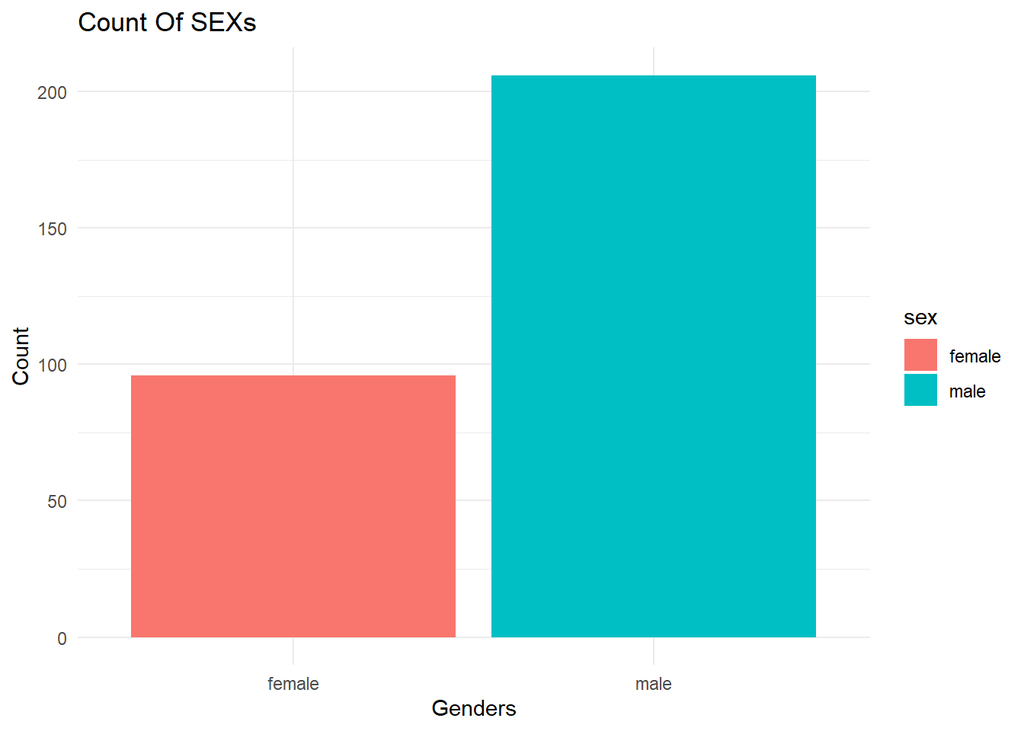

```r
ggplot(heart, aes(x = sex, fill = sex)) +
  geom_bar() +
  labs(title = "Count Of SEXs", x = "Genders", y = "Count") +
  theme_minimal()
```

Let’s see the count of different types of chest pain in our dataset.

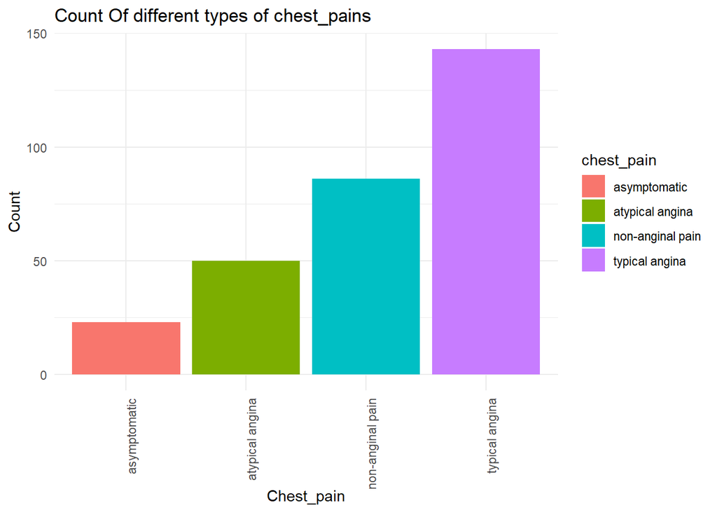

```r
ggplot(heart, aes(x = chest_pain, fill = chest_pain)) +
  geom_bar() +
  labs(title = "Count Of different types of chest_pains", x = "Chest_pain", y = "Count") +
  theme_minimal() +
  theme(axis.text.x = element_text(angle = 90, hjust = 1))
```

Let’s see the percentage distribution of fasting blood sugars.

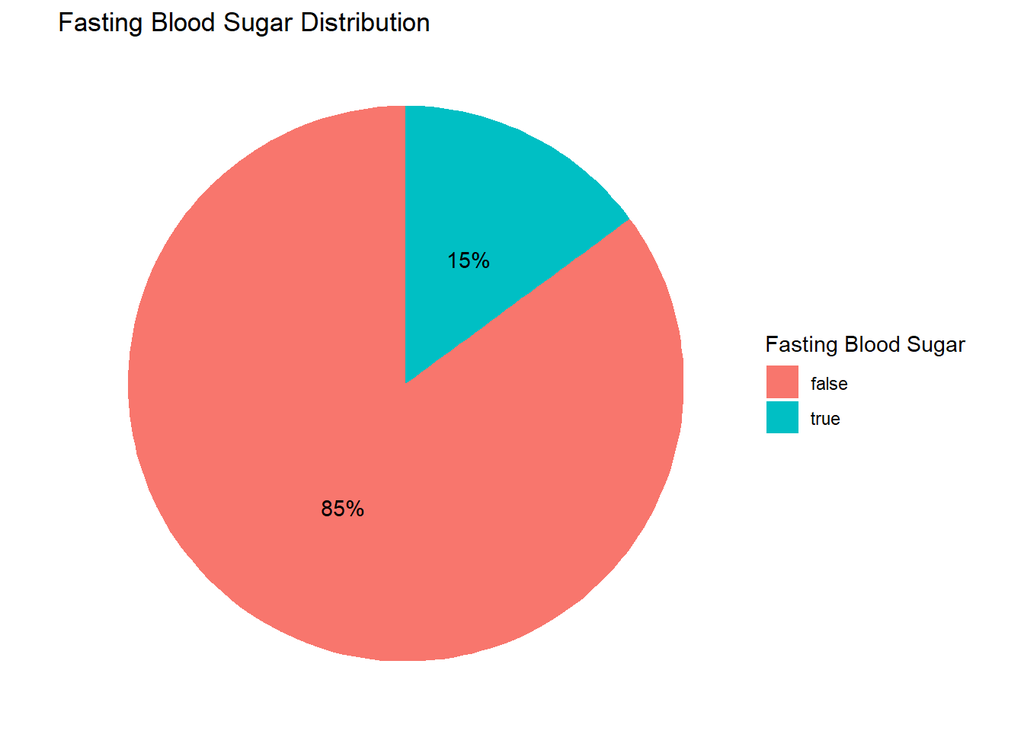

```r
data <- as.data.frame(table(heart$fasting_blood_sugar))
pie_chart <- ggplot(data, aes(x = "", y = Freq, fill = Var1)) +
  geom_bar(stat = "identity") +
  coord_polar(theta = "y") +
  geom_text(aes(label = paste0(round((Freq/sum(Freq))*100), "%")),
            position = position_stack(vjust = 0.5)) +
  labs(title = "Fasting Blood Sugar Distribution",
       fill = "Fasting Blood Sugar") +
  theme_void()
print(pie_chart)
```

Let’s see the count of resting electrocardiographic results in our dataset.

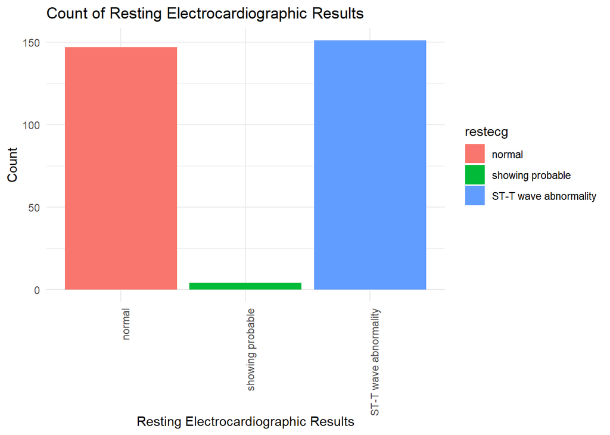

```r
ggplot(heart, aes(x = restecg, fill = restecg)) +
  geom_bar() +
  labs(title = "Count of Resting Electrocardiographic Results", x = "Resting Electrocardiographic Results", y = "Count") +
  theme_minimal() +
  theme(axis.text.x = element_text(angle = 90, hjust = 1))
```

Let’s see the percentage distribution of exercise induced angina in our dataset.

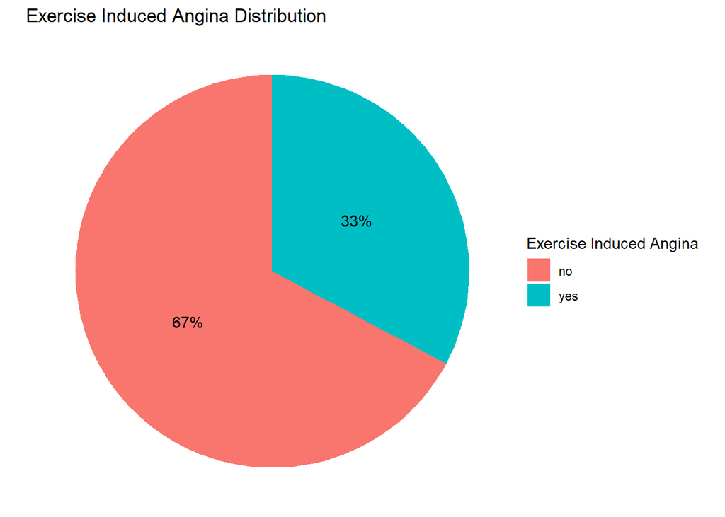

```r
data <- as.data.frame(table(heart$exercise_induced_angina))
pie_chart <- ggplot(data, aes(x = "", y = Freq, fill = Var1)) +
  geom_bar(stat = "identity") +
  coord_polar(theta = "y") +
  geom_text(aes(label = paste0(round((Freq/sum(Freq))*100), "%")),
            position = position_stack(vjust = 0.5)) +
  labs(title = "Exercise Induced Angina Distribution",
       fill = "Exercise Induced Angina") +
  theme_void()
print(pie_chart)
```

Let’s see the count of slopes in our dataset.

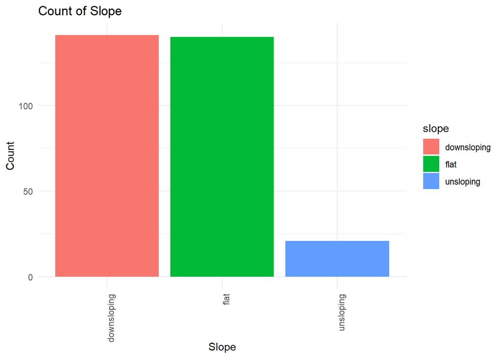

```r
ggplot(heart, aes(x = slope, fill = slope)) +
  geom_bar() +
  labs(title = "Count of Slope", x = "Slope", y = "Count") +
  theme_minimal() +
  theme(axis.text.x = element_text(angle = 90, hjust = 1))
```

Let’s see the distribution in pie chart of caa.

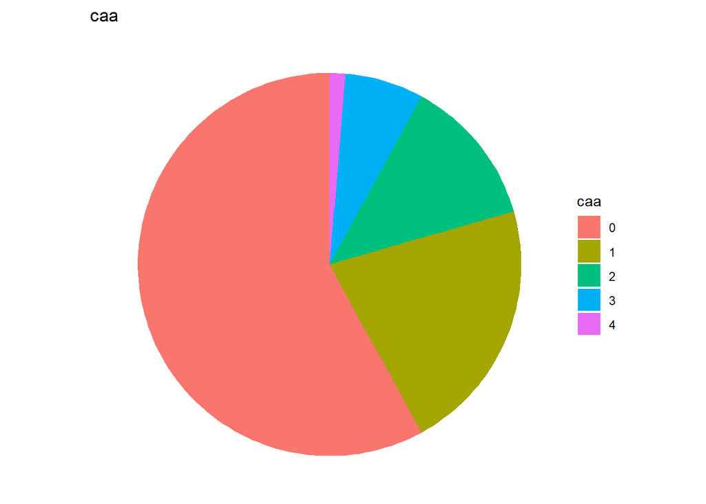

```r
data <- as.data.frame(table(heart$caa))
pie_chart <- ggplot(data, aes(x = "", y = Freq, fill = Var1)) +
  geom_bar(stat = "identity") +
  coord_polar(theta = "y") +
  labs(title = "caa",
       fill = "caa") +
  theme_void()
print(pie_chart)
```

Let’s see the count of different thalassemia in our dataset.

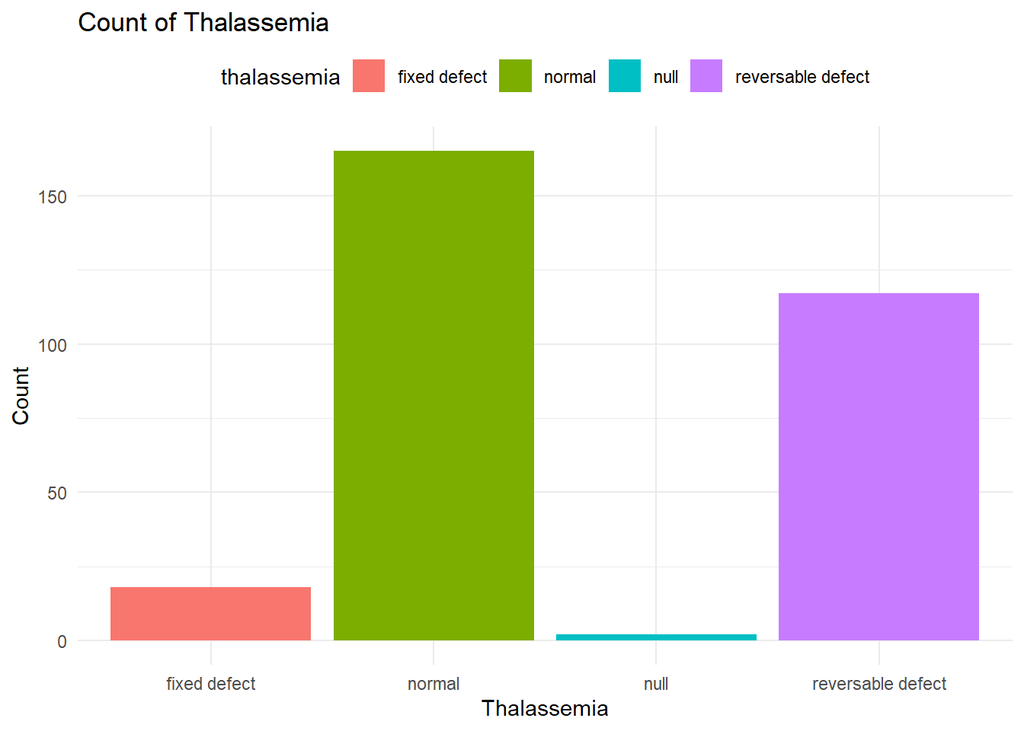

```r
ggplot(heart, aes(x = thalassemia, fill = thalassemia)) +
  geom_bar() +
  labs(title = "Count of Thalassemia", x = "Thalassemia", y = "Count") +
  theme_minimal() +
  theme(legend.position = "top")
```

Let’s see the percentage distribution of people having chances of heart attack.

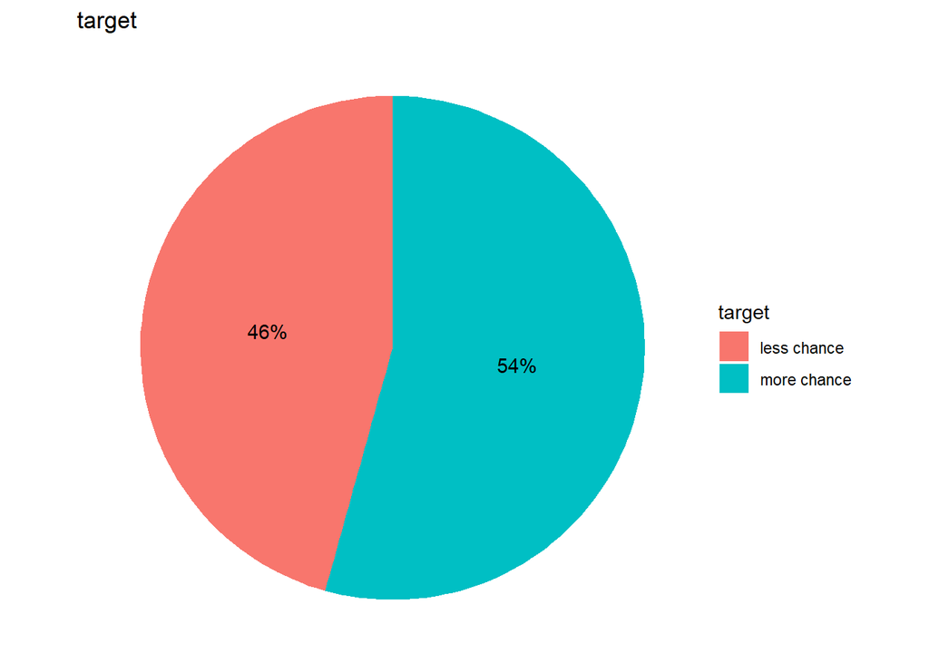

```r
data <- as.data.frame(table(heart$target))
pie_chart <- ggplot(data, aes(x = "", y = Freq, fill = Var1)) +
  geom_bar(stat = "identity") +
  coord_polar(theta = "y") +
  geom_text(aes(label = paste0(round((Freq/sum(Freq))*100), "%")),
            position = position_stack(vjust = 0.5)) +
  labs(title = "target",
       fill = "target") +
  theme_void()
print(pie_chart)
```

Let’s see the count of chest pains in different genders.

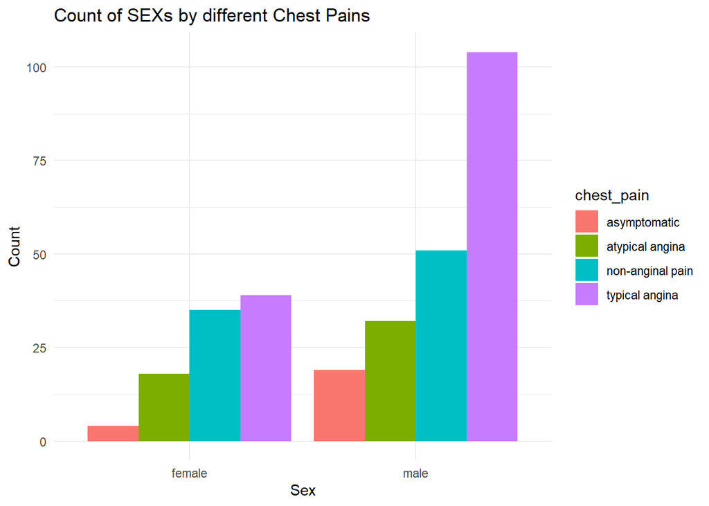

```r
sex_count <- heart %>%
  group_by(sex, chest_pain) %>%
  summarise(sex_count = n(), .groups = "drop")
ggplot(sex_count, aes(x = sex, y = sex_count, fill = chest_pain)) +
  geom_col(position = "dodge") +
  labs(title = "Count of SEXs by different Chest Pains",
       x = "Sex",
       y = "Count") +
  theme_minimal()
```

Let’s see the count of fasting blood sugar in different genders.

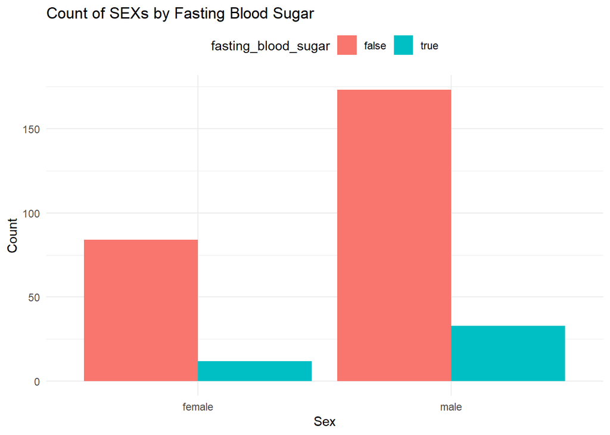

```r
count_fbs <- heart %>%
  group_by(sex, fasting_blood_sugar) %>%
  summarise(count_fbs = n(), .groups = "drop")
ggplot(count_fbs, aes(x = sex, y = count_fbs, fill = fasting_blood_sugar)) +
  geom_col(position = "dodge") +
  labs(title = "Count of SEXs by Fasting Blood Sugar",
       x = "Sex",
       y = "Count") +
  theme_minimal() +
  theme(legend.position = "top")
```

Let’s see the count of resting ecg results in different genders.

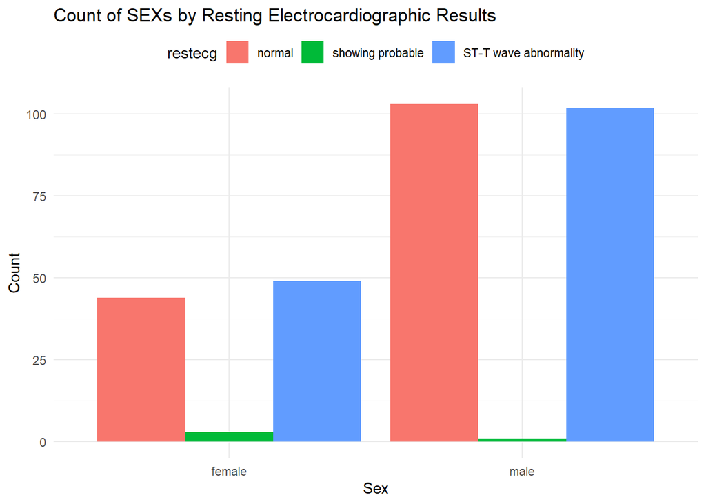

```r
count_restecg <- heart %>%
  group_by(sex, restecg) %>%
  summarise(count_restecg = n(), .groups = "drop")
ggplot(count_restecg, aes(x = sex, y = count_restecg, fill = restecg)) +
  geom_col(position = "dodge") +
  labs(title = "Count of SEXs by Resting Electrocardiographic Results",
       x = "Sex",
       y = "Count") +
  theme_minimal() +
  theme(legend.position = "top")
```

Let’s see the count of exercise induced angina in different genders.

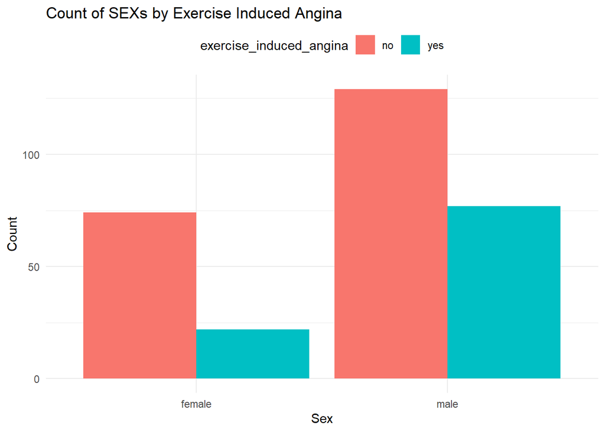

```r
count_eia <- heart %>%
  group_by(sex, exercise_induced_angina) %>%
  summarise(count_eia = n(), .groups = "drop")
ggplot(count_eia, aes(x = sex, y = count_eia, fill = exercise_induced_angina)) +
  geom_col(position = "dodge") +
  labs(title = "Count of SEXs by Exercise Induced Angina",
       x = "Sex",
       y = "Count") +
  theme_minimal() +
  theme(legend.position = "top")
```

Let’s see the count of slopes in different genders.

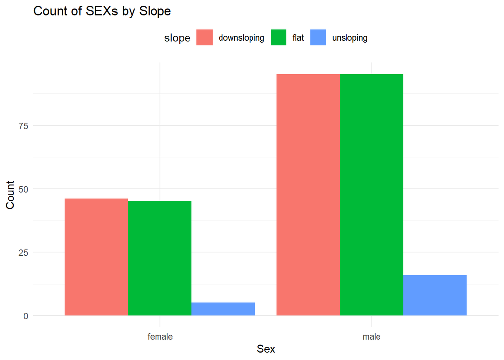

```r
count_slope <- heart %>%
  group_by(sex, slope) %>%
  summarise(count_slope = n(), .groups = "drop")
ggplot(count_slope, aes(x = sex, y = count_slope, fill = slope)) +
  geom_col(position = "dodge") +
  labs(title = "Count of SEXs by Slope",
       x = "Sex",
       y = "Count") +
  theme_minimal() +
  theme(legend.position = "top")
```

Let’s see the count of different thalassemias in different genders.

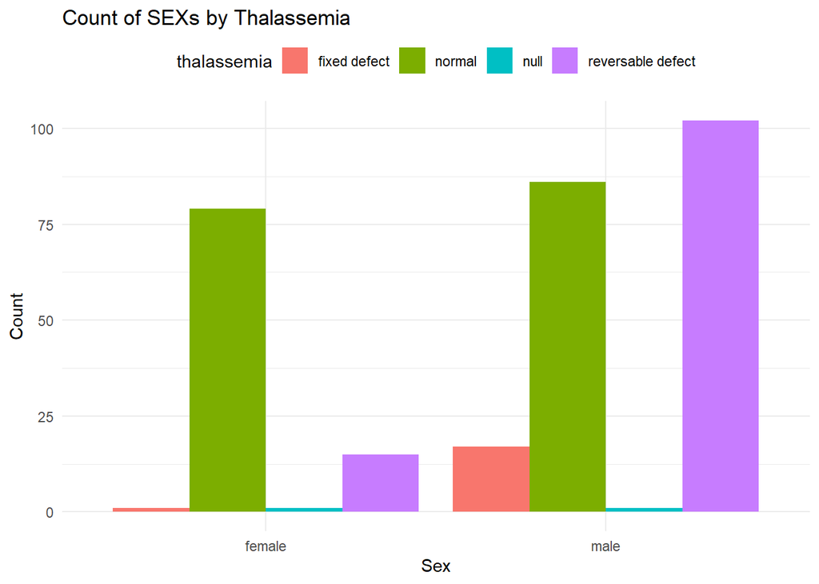

```r
count_thala <- heart %>%
  group_by(sex, thalassemia) %>%
  summarise(count_thala = n(), .groups = "drop")
ggplot(count_thala, aes(x = sex, y = count_thala, fill = thalassemia)) +
  geom_col(position = "dodge") +
  labs(title = "Count of SEXs by Thalassemia",
       x = "Sex",
       y = "Count") +
  theme_minimal() +
  theme(legend.position = "top")
```

Finally, let’s see the chance of getting heart attack in different genders.

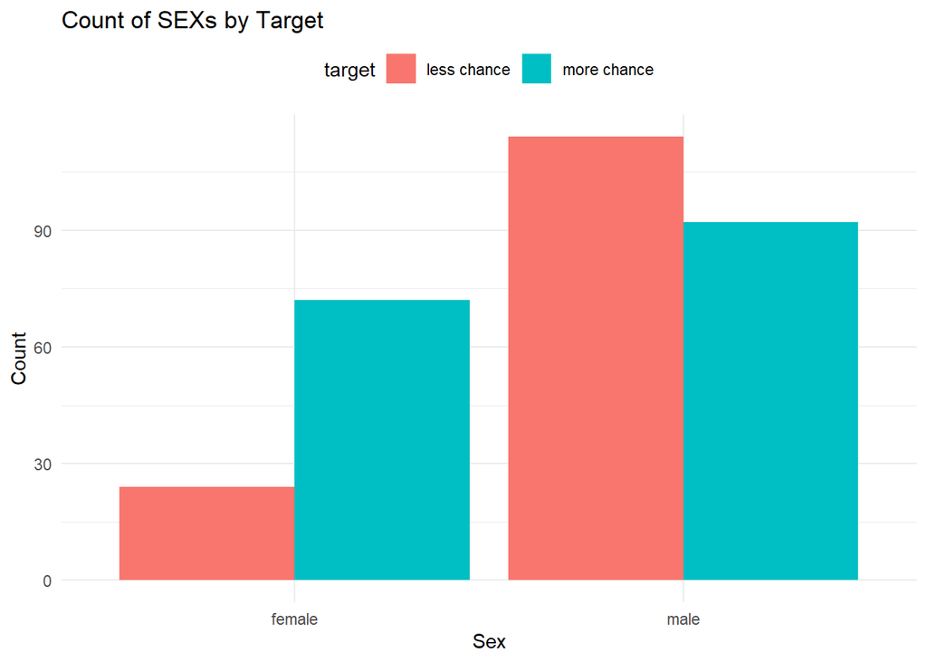

```r
count_target <- heart %>%
  group_by(sex, target) %>%
  summarise(count_target = n(), .groups = "drop")
ggplot(count_target, aes(x = sex, y = count_target, fill = target)) +
  geom_col(position = "dodge") +
  labs(title = "Count of SEXs by Target",
       x = "Sex",
       y = "Count") +
  theme_minimal() +
  theme(legend.position = "top")
```